# One Variable: Quantitative

Author

Orville D. Hombrebueno

Published

November 29, 2024

# The Data

```r
# install packages: install.packages("package")
# load packages
library(tidyverse)
library(knitr)
library(gtsummary)
library(ggstatsplot)
library(downlit)
library(broom)

# load data
data(ChickWeight)
```

## Weight versus age of chicks on different diets

The `ChickWeight` data frame has 578 rows and 4 columns from an experiment on the effect of diet on early growth of chicks.

- weight. a numeric vector giving the body weight of the chick (gm).
- Time. a numeric vector giving the number of days since birth when the measurement was made.
- Chick. an ordered factor with levels 18 < … < 48 giving a unique identifier for the chick. The ordering of the levels groups chicks on the same diet together and orders them according to their final weight (lightest to heaviest) within diet.
- Diet. a factor with levels 1, …, 4 indicating which experimental diet the chick received.

The first 6 rows of the ChickWeight data set is shown in Table 1.

```r
ChickWeight |> # call the data
  head() |> # get the first six rows of the data
  kable( # create a table
    col.names = c( # change the column names
      "Weight",
      "Time",
      "Chick",
      "Diet"
    )
  )
```

Table 1: The first 6 observations of the data set.

| Weight | Time | Chick | Diet |
| --- | --- | --- | --- |
| 42 | 0 | 1 | 1 |
| 51 | 2 | 1 | 1 |
| 59 | 4 | 1 | 1 |
| 64 | 6 | 1 | 1 |
| 76 | 8 | 1 | 1 |
| 93 | 10 | 1 | 1 |

## Descriptive Statistics

```r
ChickWeight |>
  tbl_summary(
    include = c(weight, Time, Diet),
    statistic = all_continuous() ~ "{mean} ± {sd} ({min} - {max})", # descriptive statistics
    digits = all_continuous() ~ 2, # no. of digits (rounding)
  )
```

Table 2: Summary statistics of the data set.

| **Characteristic** | **N = 578**<sup>1</sup> |
| --- | --- |
| weight | 121.82 ± 71.07 (35.00 - 373.00) |
| Time | 10.72 ± 6.76 (0.00 - 21.00) |
| Diet |  |
| 1 | 220 (38%) |
| 2 | 120 (21%) |
| 3 | 120 (21%) |
| 4 | 118 (20%) |

<sup>1</sup> Mean ± SD (Min - Max); n (%)

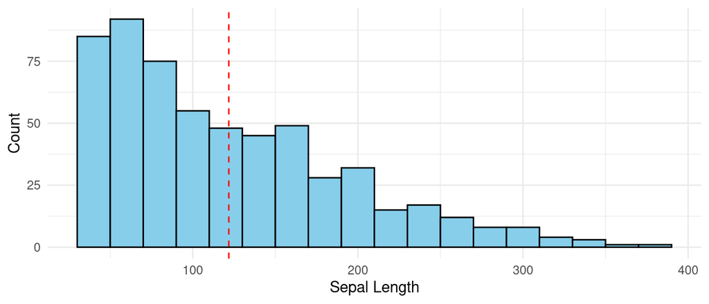

Figure 1: Histogram with mean line.

```r
mean_value <- mean(ChickWeight$weight)

ChickWeight |>
  ggplot(aes(x = weight)) +
  geom_histogram(binwidth = 20, fill = "skyblue", color = "black") +
  geom_vline(aes(xintercept = mean_value), color = "red", linetype = "dashed") +
  labs(x = "Sepal Length", y = "Count") +
  theme_minimal()
```

# Hypothesis Testing

### Research Question

Is the mean weight different from the expected average of 120 gm?

### Hypothesis and Test Statistics

- $H_0:\mu=120$; the mean weight is equal to 120 gm.
- $H_a:\mu\ne120$; the mean weigh is different from 120 gm.
- Significance level, $\alpha=5\%$.
- **one sample t-test**
- The variance is unknown.
- Data is not normally distributed.

### Results and Interpretation

The histogram and test statistics is shown on Figure 2. Based on the histogram and the *p*-value being greater than 5% (*p*-value = 0.54), we do not reject the null hypothesis. There is no sufficient evidence that the mean weight is different from 120 gm.

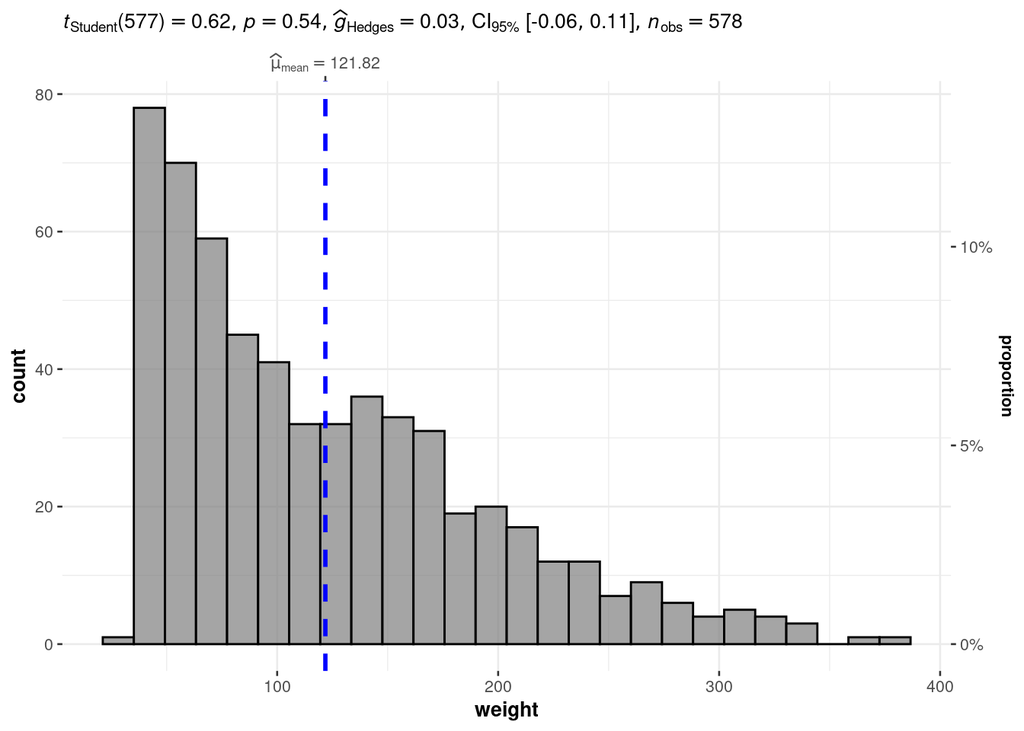

Figure 2: Histogram and test statistics.

```r
gghistostats( # create figure
  data = ChickWeight, # the data
  x = weight, # variable of interest
  type = "parametric", # for student's t-test
  test.value = 120, # default value is 0
  xlab = "weight" # label of x-axis
) +
  labs(caption = NULL) # remove caption
```